# ArchR

### Dimensionality reduction & Clustering

Because we can have maximally two accessible alleles per cell, the scATAC-seq data is sparse. Therefore, the majority of accessible regions are not transposed, meaning that most loci will have 0 accessible alleles. A zero could mean “non-accessible” or “not sampled”. For many analysis we can use a binarized matix. **Imporantly,** **the 1s have information, BUT the 0s do not!**

A PCA would result in high inter-cell similarity at all 0 positions. An alternative approach for dimensionality reduction is a **layered dimensionality reduction**. First, **Latent Semantic Indexing (LSI)** is used. LSI is an approach from language processing. Different samples are the “documents” and different regions/peaks are the “words”.

#### Iterative LSI

1. compute term frequency by depth normalizating per single cell
2. normalize by inverse document frequency -> weights features by how often they occur (differentiate between more specific and commonly accessible features)
3. you get a **TF-IDF** matrix (term frequency-inverse document frequency) which tells us how important a region/peak is to a sample
4. SVD identifies the most valuable information across samples & represented in a lower dimensional space
5. Clusters are identified with Seurat’s Shared Nearest Neighbor clustering
6. Sum accessibility across all single cells in each cluster -> log-normalize
7. Identify most variable features across the clusters
8. repeat with most variable peaks as features

With LSI we can reduce the dimensionality of the sparse insertion matrix to tens or hundreds. Then UMAP or t-SNE can be used to visualize the data

Unlike in scRNA-seq we cannot select the top highly variable features before dimensionality reduction (high noise, low reproducibility). Rather the iterative LSI approach first computes a LSI on the most accessible tiles (this will identify clusters corresponding to the major cell types). Then, ArchR computes the average accessibility across these clusters across all features. Next, the most variable peaks across these clusters are identified. The most highly accessible peaks are the features of a new round of LSI. We can set how many rounds of LSI we want to be peformed.

Using iterative LSI reduces batch effects. If you see some batch effects you could try to add more LSI iterations and start from a lower intitial clustering resolution. Also, the number of variable features can be lowered.

#### Estimated LSI

- for extremely large scATAC-seq datasets
1. subset of landmark cells (randomly selected) are used for LSI
2. remaining cells are TF-IDF normlaized using the IDF determined from the landmark cells from step one
3. normalized cells are porjected into the SVD space defined by the landmark cells

The LSI transformation is, therefore, based on a subset of cells only and the remaining cells are projected into this landmark LSI. This approach minimizes memory usage. The landmark set size depends on cell type proportions.

- iterative LSI dimensionality reduction -> explore the parameters!

#### Batch correct with Harmony

- dimensionality reduction object from ArchR isp passed to Harmony

```r
proj <- addIterativeLSI(ArchRProj = proj, useMatrix = "TileMatrix", name = "IterativeLSI")
```

```
## Checking Inputs...
```

```
## ArchR logging to : ArchRLogs/ArchR-addIterativeLSI-11d4745a88a88-Date-2022-01-31_Time-17-07-56.log
## If there is an issue, please report to github with logFile!
```

```
## 2022-01-31 17:07:57 : Computing Total Across All Features, 0.002 mins elapsed.
```

```
## 2022-01-31 17:07:58 : Computing Top Features, 0.029 mins elapsed.
```

```
## ###########
## 2022-01-31 17:08:00 : Running LSI (1 of 2) on Top Features, 0.051 mins elapsed.
## ###########
```

```
## 2022-01-31 17:08:00 : Sampling Cells (N = 10001) for Estimated LSI, 0.052 mins elapsed.
```

```
## 2022-01-31 17:08:00 : Creating Sampled Partial Matrix, 0.052 mins elapsed.
```

```
## 2022-01-31 17:08:08 : Computing Estimated LSI (projectAll = FALSE), 0.193 mins elapsed.
```

```
## 2022-01-31 17:08:29 : Identifying Clusters, 0.537 mins elapsed.
```

```
## 2022-01-31 17:08:43 : Identified 6 Clusters, 0.778 mins elapsed.
```

```
## 2022-01-31 17:08:43 : Saving LSI Iteration, 0.778 mins elapsed.
```

```
## 2022-01-31 17:09:06 : Creating Cluster Matrix on the total Group Features, 1.162 mins elapsed.
```

```
## 2022-01-31 17:09:35 : Computing Variable Features, 1.643 mins elapsed.
```

```
## ###########
## 2022-01-31 17:09:35 : Running LSI (2 of 2) on Variable Features, 1.646 mins elapsed.
## ###########
```

```
## 2022-01-31 17:09:35 : Creating Partial Matrix, 1.646 mins elapsed.
```

```
## 2022-01-31 17:09:43 : Computing LSI, 1.778 mins elapsed.
```

```
## 2022-01-31 17:10:03 : Finished Running IterativeLSI, 2.1 mins elapsed.
```

```
proj <- addIterativeLSI(
    ArchRProj = proj,
    useMatrix = "TileMatrix",
    name = "IterativeLSI",
    iterations = 2,
    clusterParams = list( #See Seurat::FindClusters
        resolution = c(0.2),
        sampleCells = 10000,
        n.start = 10
    ),
    varFeatures = 25000,
    dimsToUse = 1:30
)
```

- Calling clusters in this new space uses the Seurat’s graph clustering function as default clustering method. The Seurat method first computs KNN graph and then a modularity optimization technique to cluster the cells (iteratively group cells togetether with Louvian algorithm using 10 random starts). Another option is to use “Scran”. The default number of nearest neighbors used is 10. The minimum number of cells for a cluster to be called a cluster is set to 5 by default. The maximum number of clusters to be called is set to 25 by default.

```r
proj <- addClusters(input = proj, reducedDims = "IterativeLSI")
```

```
## ArchR logging to : ArchRLogs/ArchR-addClusters-11d47641e602e-Date-2022-01-31_Time-17-10-04.log
## If there is an issue, please report to github with logFile!
```

```
## 2022-01-31 17:10:05 : Running Seurats FindClusters (Stuart et al. Cell 2019), 0.002 mins elapsed.
```

```
## Modularity Optimizer version 1.3.0 by Ludo Waltman and Nees Jan van Eck
##
## Number of nodes: 10250
## Number of edges: 473760
##
## Running Louvain algorithm...
## Maximum modularity in 10 random starts: 0.8640
## Number of communities: 13
## Elapsed time: 1 seconds
```

```
## 2022-01-31 17:10:19 : Testing Outlier Clusters, 0.234 mins elapsed.
```

```
## 2022-01-31 17:10:19 : Assigning Cluster Names to 13 Clusters, 0.234 mins elapsed.
```

```
## 2022-01-31 17:10:19 : Finished addClusters, 0.236 mins elapsed.
```

### Visualizing a UMAP embedding

- uses uwot package
- various attributes of the data can be visualized
  - these are stored in a matrix called `cellColData`
  - which variable the plot is colored by is specified by `colorBy` and `name` parameter

```r
proj <- addUMAP(ArchRProj = proj, reducedDims = "IterativeLSI")
```

```
## 17:10:38 Creating temp model dir /tmp/RtmpifZcxX/dir11d474764c587
## 17:10:38 Creating dir /tmp/RtmpifZcxX/dir11d474764c587
## 17:10:39 Changing to /tmp/RtmpifZcxX/dir11d474764c587
## 17:10:39 Creating /omics/groups/OE0533/internal/katharina/scDoRI/ArchR/ArchRVignette/Embeddings/Save-Uwot-UMAP-Params-IterativeLSI-11d472a1e267a-Date-2022-01-31_Time-17-10-38.tar
```

```r
# color by sample
p1 <- plotEmbedding(ArchRProj = proj, colorBy = "cellColData", name = "Sample", embedding = "UMAP")
```

```
## ArchR logging to : ArchRLogs/ArchR-plotEmbedding-11d475dc92c3e-Date-2022-01-31_Time-17-10-40.log
## If there is an issue, please report to github with logFile!
```

```
## Getting UMAP Embedding
```

```
## ColorBy = cellColData
```

```
## Plotting Embedding
```

```
## 1
## ArchR logging successful to : ArchRLogs/ArchR-plotEmbedding-11d475dc92c3e-Date-2022-01-31_Time-17-10-40.log
```

```r
# color by cluster
p2 <- plotEmbedding(ArchRProj = proj, colorBy = "cellColData", name = "Clusters", embedding = "UMAP")
```

```
## ArchR logging to : ArchRLogs/ArchR-plotEmbedding-11d47153eade1-Date-2022-01-31_Time-17-10-42.log
## If there is an issue, please report to github with logFile!
## Getting UMAP Embedding
## ColorBy = cellColData
## Plotting Embedding
## 1
## ArchR logging successful to : ArchRLogs/ArchR-plotEmbedding-11d47153eade1-Date-2022-01-31_Time-17-10-42.log
```

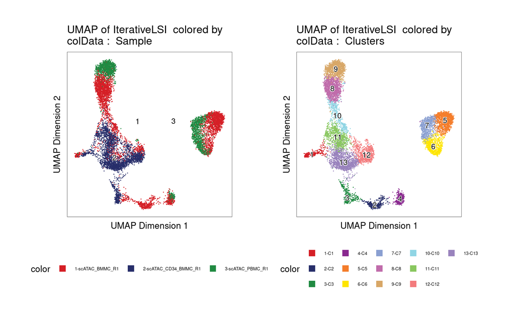

```r
ggAlignPlots(p1, p2, type = "h")
```

### Cluster assignment using gene scores

For the toy dataset marker genes of known hematopoietic regulators can be used. Using MAGIC we add imputation weights to smooth the dropout noise in the gene scores

```r
proj <- addImputeWeights(proj)
```

```
## ArchR logging to : ArchRLogs/ArchR-addImputeWeights-11d474c129761-Date-2022-01-31_Time-17-10-47.log
## If there is an issue, please report to github with logFile!
```

```
## 2022-01-31 17:10:48 : Computing Impute Weights Using Magic (Cell 2018), 0 mins elapsed.
```

```r
markerGenes  <- c(
    "CD34",  #Early Progenitor
    "GATA1", #Erythroid
    "PAX5", "MS4A1", "MME", #B-Cell Trajectory
    "CD14", "MPO", #Monocytes
    "CD3D", "CD8A"#TCells
  )
```

```r
p <- plotEmbedding(
    ArchRProj = proj,
    colorBy = "GeneScoreMatrix",
    name = markerGenes,
    embedding = "UMAP",
    imputeWeights = getImputeWeights(proj)
)
```

```
## Getting ImputeWeights
```

```
## ArchR logging to : ArchRLogs/ArchR-plotEmbedding-11d47568eca4a-Date-2022-01-31_Time-17-11-12.log
## If there is an issue, please report to github with logFile!
```

```
## Getting UMAP Embedding
```

```
## ColorBy = GeneScoreMatrix
```

```
## Getting Matrix Values...
```

```
## 2022-01-31 17:11:13 :
```

```
## 1 2 3
## Imputing Matrix
## Using weights on disk
## 1 of 2
## 2 of 2
## Using weights on disk
## 1 of 2
## 2 of 2
## Plotting Embedding
## 1 2 3 4 5 6 7 8 9
## ArchR logging successful to : ArchRLogs/ArchR-plotEmbedding-11d47568eca4a-Date-2022-01-31_Time-17-11-12.log
```

### Visualizing Genome Browser Tracks

Browse local chromatin accessibility at marker genes. Plot genome browser tracks per cluster

```r
p <- plotBrowserTrack(
    ArchRProj = proj,
    groupBy = "Clusters",
    geneSymbol = markerGenes,
    upstream = 50000,
    downstream = 50000
)
```

```
## ArchR logging to : ArchRLogs/ArchR-plotBrowserTrack-11d479e49f8a-Date-2022-01-31_Time-17-11-31.log
## If there is an issue, please report to github with logFile!
```

```
## 2022-01-31 17:11:32 : Validating Region, 0.01 mins elapsed.
```

```
## GRanges object with 9 ranges and 2 metadata columns:
##       seqnames              ranges strand |     gene_id      symbol
##          <Rle>           <IRanges>  <Rle> | <character> <character>
##   [1]     chr1 208059883-208084683      - |         947        CD34
##   [2]     chrX   48644982-48652717      + |        2623       GATA1
##   [3]     chr9   36838531-37034476      - |        5079        PAX5
##   [4]    chr11   60223282-60238225      + |         931       MS4A1
##   [5]     chr3 154741913-154901518      + |        4311         MME
##   [6]     chr5 140011313-140013286      - |         929        CD14
##   [7]    chr17   56347217-56358296      - |        4353         MPO
##   [8]    chr11 118209789-118213459      - |         915        CD3D
##   [9]     chr2   87011728-87035519      - |         925        CD8A
##   -------
##   seqinfo: 24 sequences from hg19 genome
```

```
## 2022-01-31 17:11:32 : Adding Bulk Tracks (1 of 9), 0.012 mins elapsed.
```

```
## Getting Region From Arrow Files 1 of 3
```

```
## Getting Region From Arrow Files 2 of 3
```

```
## Getting Region From Arrow Files 3 of 3
```

```
## 2022-01-31 17:11:33 : Adding Gene Tracks (1 of 9), 0.03 mins elapsed.
```

```
## 2022-01-31 17:11:34 : Plotting, 0.034 mins elapsed.
```

```
## 2022-01-31 17:11:35 : Adding Bulk Tracks (2 of 9), 0.059 mins elapsed.
```

```
## Getting Region From Arrow Files 1 of 3
```

```
## Getting Region From Arrow Files 2 of 3
```

```
## Getting Region From Arrow Files 3 of 3
```

```
## 2022-01-31 17:11:36 : Adding Gene Tracks (2 of 9), 0.074 mins elapsed.
```

```
## 2022-01-31 17:11:36 : Plotting, 0.078 mins elapsed.
```

```
## 2022-01-31 17:11:37 : Adding Bulk Tracks (3 of 9), 0.096 mins elapsed.
```

```
## Getting Region From Arrow Files 1 of 3
```

```
## Getting Region From Arrow Files 2 of 3
```

```
## Getting Region From Arrow Files 3 of 3
```

```
## 2022-01-31 17:11:38 : Adding Gene Tracks (3 of 9), 0.109 mins elapsed.
```

```
## 2022-01-31 17:11:38 : Plotting, 0.112 mins elapsed.
```

```
## 2022-01-31 17:11:40 : Adding Bulk Tracks (4 of 9), 0.137 mins elapsed.
```

```
## Getting Region From Arrow Files 1 of 3
```

```
## Getting Region From Arrow Files 2 of 3
```

```
## Getting Region From Arrow Files 3 of 3
```

```
## 2022-01-31 17:11:41 : Adding Gene Tracks (4 of 9), 0.152 mins elapsed.
```

```
## 2022-01-31 17:11:41 : Plotting, 0.157 mins elapsed.
```

```
## 2022-01-31 17:11:42 : Adding Bulk Tracks (5 of 9), 0.172 mins elapsed.
```

```
## Getting Region From Arrow Files 1 of 3
```

```
## Getting Region From Arrow Files 2 of 3
```

```
## Getting Region From Arrow Files 3 of 3
```

```
## 2022-01-31 17:11:43 : Adding Gene Tracks (5 of 9), 0.187 mins elapsed.
```

```
## 2022-01-31 17:11:43 : Plotting, 0.192 mins elapsed.
```

```
## 2022-01-31 17:11:44 : Adding Bulk Tracks (6 of 9), 0.207 mins elapsed.
```

```
## Getting Region From Arrow Files 1 of 3
```

```
## Getting Region From Arrow Files 2 of 3
```

```
## Getting Region From Arrow Files 3 of 3
```

```
## 2022-01-31 17:11:45 : Adding Gene Tracks (6 of 9), 0.22 mins elapsed.
```

```
## 2022-01-31 17:11:45 : Plotting, 0.225 mins elapsed.
```

```
## 2022-01-31 17:11:46 : Adding Bulk Tracks (7 of 9), 0.249 mins elapsed.
```

```
## Getting Region From Arrow Files 1 of 3
```

```
## Getting Region From Arrow Files 2 of 3
```

```
## Getting Region From Arrow Files 3 of 3
```

```
## 2022-01-31 17:11:47 : Adding Gene Tracks (7 of 9), 0.264 mins elapsed.
```

```
## 2022-01-31 17:11:48 : Plotting, 0.269 mins elapsed.
```

```
## 2022-01-31 17:11:49 : Adding Bulk Tracks (8 of 9), 0.298 mins elapsed.
```

```
## Getting Region From Arrow Files 1 of 3
```

```
## Getting Region From Arrow Files 2 of 3
```

```
## Getting Region From Arrow Files 3 of 3
```

```
## 2022-01-31 17:11:50 : Adding Gene Tracks (8 of 9), 0.314 mins elapsed.
```

```
## 2022-01-31 17:11:51 : Plotting, 0.318 mins elapsed.
```

```
## 2022-01-31 17:11:52 : Adding Bulk Tracks (9 of 9), 0.339 mins elapsed.
```

```
## Getting Region From Arrow Files 1 of 3
```

```
## Getting Region From Arrow Files 2 of 3
```

```
## Getting Region From Arrow Files 3 of 3
```

```
## 2022-01-31 17:11:53 : Adding Gene Tracks (9 of 9), 0.356 mins elapsed.
```

```
## 2022-01-31 17:11:53 : Plotting, 0.36 mins elapsed.
```

```
## ArchR logging successful to : ArchRLogs/ArchR-plotBrowserTrack-11d479e49f8a-Date-2022-01-31_Time-17-11-31.log
```

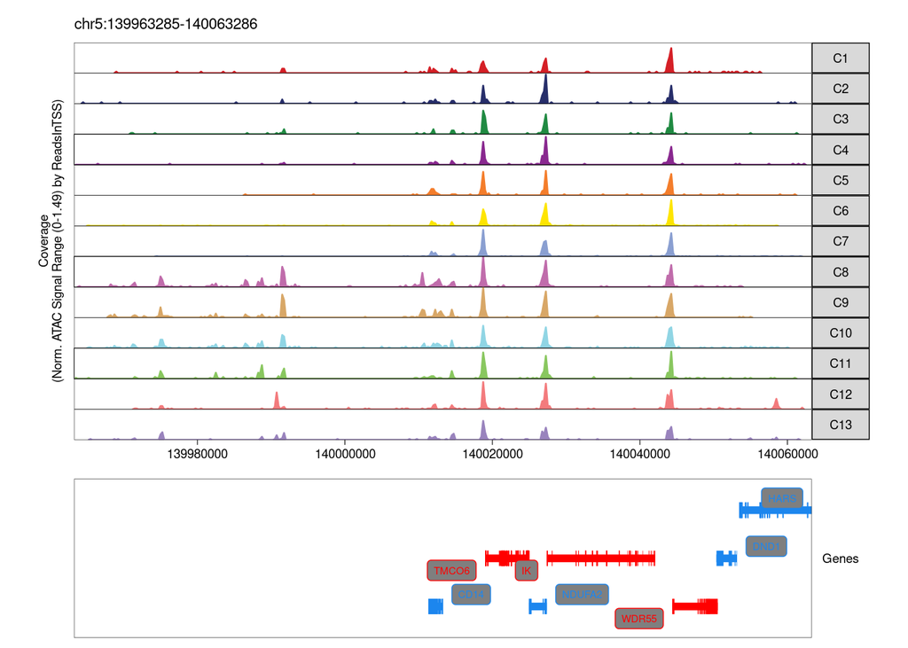

```r
grid::grid.newpage()
grid::grid.draw(p$CD14)
```

```r
saveArchRProject(proj, outputDirectory = "ArchRVignette", load = FALSE)
```

```
## Saving ArchRProject...
```

## Integration with scRNA-seq

- the scATAC-seq gene score matrix is compared with the scRNA-seq gene expression matrix
- for this alignment the `FindTransferAnchors()` function from Seurat is used
- to scale for large sample size, this process is parallelized
- for each cell in ATAC we find the cell in scRNA-seq that looks most similar -> assign the correpsonding gene expression to that cell.

Apart from using this information for identifying clusters we can also use it for identifying predicted cis-regulatory elements.

```r
if(!file.exists("scRNA-Hematopoiesis-Granja-2019.rds")){
    download.file(
        url = "https://jeffgranja.s3.amazonaws.com/ArchR/TestData/scRNA-Hematopoiesis-Granja-2019.rds",
        destfile = "scRNA-Hematopoiesis-Granja-2019.rds"
    )
}

# ranged summarized Experiment
seRNA <- readRDS("scRNA-Hematopoiesis-Granja-2019.rds")
seRNA
```

```
## class: RangedSummarizedExperiment
## dim: 20287 35582
## metadata(0):
## assays(1): counts
## rownames(20287): FAM138A OR4F5 ... S100B PRMT2
## rowData names(3): gene_name gene_id exonLength
## colnames(35582): CD34_32_R5:AAACCTGAGTATCGAA-1
##   CD34_32_R5:AAACCTGAGTCGTTTG-1 ...
##   BMMC_10x_GREENLEAF_REP2:TTTGTTGCATGTGTCA-1
##   BMMC_10x_GREENLEAF_REP2:TTTGTTGCATTGAAAG-1
## colData names(10): Group nUMI_pre ... BioClassification Barcode
```

```r
table(colData(seRNA)$BioClassification)
```

```
##
##         01_HSC 02_Early.Eryth  03_Late.Eryth  04_Early.Baso    05_CMP.LMPP
##           1425           1653            446            111           2260
##       06_CLP.1         07_GMP    08_GMP.Neut         09_pDC         10_cDC
##            903           2097           1050            544            325
## 11_CD14.Mono.1 12_CD14.Mono.2   13_CD16.Mono         14_Unk       15_CLP.2
##           1800           4222            292            520            377
##       16_Pre.B           17_B      18_Plasma       19_CD8.N      20_CD4.N1
##            710           1711             62           1521           2470
##      21_CD4.N2       22_CD4.M      23_CD8.EM      24_CD8.CM          25_NK
##           2364           3539            796           2080           2143
##         26_Unk
##            161
```

### Unconstrained & Constrained integration

**Unconstrained integration:**

- takes all cells of scATAC-seq data and attempts to align them to any of the scRNA-seq cells
- this provides preliminary cluster identities which will serve as prior knowledge for the constrained integration
- the quality can be improved by constraining the integration

The integration matrix will be stored in the ArchR project via `matrixName`. The other parameters will be saved in the cellColData (nameCell = store matched cell ID from scRNA-seq, nameGroup = store group ID from scRNA-seq, nameScore = store cross-platform integration score)

```r
proj <- addGeneIntegrationMatrix(
    ArchRProj = proj,
    useMatrix = "GeneScoreMatrix",
    matrixName = "GeneIntegrationMatrix",
    reducedDims = "IterativeLSI",
    seRNA = seRNA,
    addToArrow = FALSE,
    groupRNA = "BioClassification", # Bioclassification is a column in
    # the colData of the seRNA object, this column will be used to
    # determine the subgroupings specified in groupList for constrained integration
    # it is also used for the nameGroup output of this function
    nameCell = "predictedCell_Un", # name the cellColData for the
    # predicted scRNA-seq cell in the specified ArchRProject ->
    # will add a column to the project
    nameGroup = "predictedGroup_Un",
    nameScore = "predictedScore_Un"
)
```

```
## ArchR logging to : ArchRLogs/ArchR-addGeneIntegrationMatrix-11d476cacd979-Date-2022-01-31_Time-17-13-26.log
## If there is an issue, please report to github with logFile!
```

```
## 2022-01-31 17:13:27 : Running Seurat's Integration Stuart* et al 2019, 0.012 mins elapsed.
```

```
## 2022-01-31 17:13:28 : Checking ATAC Input, 0.023 mins elapsed.
```

```
## 2022-01-31 17:13:28 : Checking RNA Input, 0.023 mins elapsed.
```

```
## 2022-01-31 17:13:34 : Found 18601 overlapping gene names from gene scores and rna matrix!, 0.13 mins elapsed.
```

```
## 2022-01-31 17:13:34 : Creating Integration Blocks, 0.13 mins elapsed.
```

```
## 2022-01-31 17:13:34 : Prepping Interation Data, 0.135 mins elapsed.
```

```
## 2022-01-31 17:13:35 : Computing Integration in 1 Integration Blocks!, 0 mins elapsed.
```

```
## 2022-01-31 17:13:35 : Block (1 of 1) : Computing Integration, 0 mins elapsed.
```

```
## 2022-01-31 17:13:37 : Block (1 of 1) : Identifying Variable Genes, 0.035 mins elapsed.
```

```
## 2022-01-31 17:13:39 : Block (1 of 1) : Getting GeneScoreMatrix, 0.077 mins elapsed.
```

```
## 2022-01-31 17:13:46 : Block (1 of 1) : Imputing GeneScoreMatrix, 0.181 mins elapsed.
```

```
## Getting ImputeWeights
```

```
## 2022-01-31 17:14:41 : Block (1 of 1) : Seurat FindTransferAnchors, 1.104 mins elapsed.
```

```
## 2022-01-31 17:16:33 : Block (1 of 1) : Seurat TransferData Cell Group Labels, 2.966 mins elapsed.
```

```
## 2022-01-31 17:16:35 : Block (1 of 1) : Seurat TransferData Cell Names Labels, 3.004 mins elapsed.
```

```
## 2022-01-31 17:16:53 : Block (1 of 1) : Saving TransferAnchors Joint CCA, 3.298 mins elapsed.
```

```
## 2022-01-31 17:16:54 : Block (1 of 1) : Completed Integration, 3.322 mins elapsed.
```

```
## 2022-01-31 17:16:55 : Block (1 of 1) : Plotting Joint UMAP, 3.334 mins elapsed.
```

```
## Length of unique values greater than palette, interpolating..
```

```
## 2022-01-31 17:17:42 : Completed Integration with RNA Matrix, 4.114 mins elapsed.
```

```
## ArchR logging successful to : ArchRLogs/ArchR-addGeneIntegrationMatrix-11d476cacd979-Date-2022-01-31_Time-17-13-26.log
```

**Constrained integration:**

- prior knowledge of the cell types is used to limit the search space of the alignment -> e.g. if we know that clusters A, B, C in scATAC-seq data correspond to 3 different T cell clusters and Clusters X, Y in scRNA-seq data correspond to two T cell clusters, we could try to specifically align these cells
1. Identify which cell types from scRNA-seq data are most abundant in scATAC-seq clusters?
2. confusion matrix is created that looks at the intersection of Clusters and predicted group which contains the cell types as identfied by scRNA-seq
3. This shows which scRNA-seq cell type is most abundant in each of the scATAC clusters

```r
# in the confusion matrix the rows correspond to clusters in scATAC data
# the columns correspond to cell types in scRNA-seq data
cM <- as.matrix(confusionMatrix(proj$Clusters, proj$predictedGroup_Un))
cM[, 1:5]
```

```
##     17_B 16_Pre.B 08_GMP.Neut 25_NK 11_CD14.Mono.1
## C4   407        1           0     1              0
## C2     3      330           0     2              0
## C10    3        0         276     0             74
## C6     0        0           0   570              0
## C8     0        0           6     0           1237
## C12    0        0          26     5              0
## C5     0        0           0     4              0
## C11    0        0         751     0              2
## C7     0        0           0    14              0
## C13    0        0          60     2              0
## C1     0        0           0     0              0
## C9     2        0           3     0            366
## C3     0        1           1     0              0
```

```r
preClust <- colnames(cM)[apply(cM, 1 , which.max)]
cbind(preClust, rownames(cM)) #Assignments
```

```
##       preClust
##  [1,] "17_B"           "C4"
##  [2,] "16_Pre.B"       "C2"
##  [3,] "08_GMP.Neut"    "C10"
##  [4,] "25_NK"          "C6"
##  [5,] "11_CD14.Mono.1" "C8"
##  [6,] "02_Early.Eryth" "C12"
##  [7,] "21_CD4.N2"      "C5"
##  [8,] "08_GMP.Neut"    "C11"
##  [9,] "22_CD4.M"       "C7"
## [10,] "01_HSC"         "C13"
## [11,] "09_pDC"         "C1"
## [12,] "12_CD14.Mono.2" "C9"
## [13,] "15_CLP.2"       "C3"
```

Which cells in the scRNA-seq correspond to Tcells and NK cells?

Use pattern matching strings in combination with grep to extract the scATAC-seq clusters that correspond to these scRNA-seq cell types. | acts as an or statement, so we search for any row in the preClust column of the confusion matix that matches a scRNA-seq cluster number.

```r
unique(proj$predictedGroup_Un)
```

```
##  [1] "17_B"           "16_Pre.B"       "08_GMP.Neut"    "25_NK"
##  [5] "11_CD14.Mono.1" "07_GMP"         "02_Early.Eryth" "24_CD8.CM"
##  [9] "05_CMP.LMPP"    "03_Late.Eryth"  "22_CD4.M"       "09_pDC"
## [13] "21_CD4.N2"      "15_CLP.2"       "01_HSC"         "19_CD8.N"
## [17] "12_CD14.Mono.2" "20_CD4.N1"      "06_CLP.1"       "04_Early.Baso"
## [21] "26_Unk"         "23_CD8.EM"      "13_CD16.Mono"
```

```r
cTNK <- paste0(paste0(19:25), collapse = "|")
cTNK
```

```
## [1] "19|20|21|22|23|24|25"
```

```r
cNonTNK <- paste0(c(paste0("0", 1:9), 10:13, 15:18), collapse = "|")
cNonTNK
```

```
## [1] "01|02|03|04|05|06|07|08|09|10|11|12|13|15|16|17|18"
```

```r
clustTNK <- rownames(cM)[grep(cTNK, preClust)]
clustTNK
```

```
## [1] "C6" "C5" "C7"
```

```r
clustNonTNK <- rownames(cM)[grep(cNonTNK, preClust)]
clustNonTNK
```

```
##  [1] "C4"  "C2"  "C10" "C8"  "C12" "C11" "C13" "C1"  "C9"  "C3"
```

Identify scRNA-seq cells corresponding to the same cell types.

```r
#RNA get cells in these categories
rnaTNK <- colnames(seRNA)[grep(cTNK, colData(seRNA)$BioClassification)]
head(rnaTNK)
```

```
## [1] "PBMC_10x_GREENLEAF_REP1:AAACCCAGTCGTCATA-1"
## [2] "PBMC_10x_GREENLEAF_REP1:AAACCCATCCGATGTA-1"
## [3] "PBMC_10x_GREENLEAF_REP1:AAACCCATCTCAACGA-1"
## [4] "PBMC_10x_GREENLEAF_REP1:AAACCCATCTCTCGAC-1"
## [5] "PBMC_10x_GREENLEAF_REP1:AAACGAACAATCGTCA-1"
## [6] "PBMC_10x_GREENLEAF_REP1:AAACGAACACGATTCA-1"
```

```r
# get cell not in these categories
rnaNonTNK <- colnames(seRNA)[grep(cNonTNK, colData(seRNA)$BioClassification)]
head(rnaNonTNK)
```

```
## [1] "CD34_32_R5:AAACCTGAGTATCGAA-1" "CD34_32_R5:AAACCTGAGTCGTTTG-1"
## [3] "CD34_32_R5:AAACCTGGTTCCACAA-1" "CD34_32_R5:AAACGGGAGCTTCGCG-1"
## [5] "CD34_32_R5:AAACGGGAGGGAGTAA-1" "CD34_32_R5:AAACGGGAGTTACGGG-1"
```

We create a nested list with two vectors of cell IDs

```r
groupList <- SimpleList(
    TNK = SimpleList(
        ATAC = proj$cellNames[proj$Clusters %in% clustTNK],
        RNA = rnaTNK
    ),
    NonTNK = SimpleList(
        ATAC = proj$cellNames[proj$Clusters %in% clustNonTNK],
        RNA = rnaNonTNK
    )
)

groupList[[1]][[1]] %>% head
```

```
## [1] "scATAC_BMMC_R1#GTAGGAGCATTATGGC-1" "scATAC_BMMC_R1#CTAGGATTCTATGAGC-1"
## [3] "scATAC_BMMC_R1#AGTTTGGCACGCGCAT-1" "scATAC_BMMC_R1#GCAGATTGTATGGGTG-1"
## [5] "scATAC_BMMC_R1#ACATGGTCAGTATCTG-1" "scATAC_BMMC_R1#AGATTCGCATAGTCCA-1"
```

```r
proj <- addGeneIntegrationMatrix(
    ArchRProj = proj,
    useMatrix = "GeneScoreMatrix",
    matrixName = "GeneIntegrationMatrix",
    reducedDims = "IterativeLSI",
    seRNA = seRNA,
    addToArrow = FALSE,
    groupList = groupList,
    groupRNA = "BioClassification",
    nameCell = "predictedCell_Co",
    nameGroup = "predictedGroup_Co",
    nameScore = "predictedScore_Co"
)
```

```
## ArchR logging to : ArchRLogs/ArchR-addGeneIntegrationMatrix-11d472477d78b-Date-2022-01-31_Time-17-17-44.log
## If there is an issue, please report to github with logFile!
```

```
## 2022-01-31 17:17:45 : Running Seurat's Integration Stuart* et al 2019, 0.011 mins elapsed.
```

```
## 2022-01-31 17:17:45 : Checking ATAC Input, 0.02 mins elapsed.
```

```
## 2022-01-31 17:17:45 : Checking RNA Input, 0.02 mins elapsed.
```

```
## 2022-01-31 17:17:54 : Found 18601 overlapping gene names from gene scores and rna matrix!, 0.174 mins elapsed.
```

```
## 2022-01-31 17:17:54 : Creating Integration Blocks, 0.174 mins elapsed.
```

```
## 2022-01-31 17:17:55 : Prepping Interation Data, 0.177 mins elapsed.
```

```
## 2022-01-31 17:17:55 : Computing Integration in 2 Integration Blocks!, 0 mins elapsed.
```

```
## 2022-01-31 17:17:55 : Block (1 of 2) : Computing Integration, 0 mins elapsed.
```

```
## 2022-01-31 17:17:57 : Block (1 of 2) : Identifying Variable Genes, 0.027 mins elapsed.
```

```
## 2022-01-31 17:17:59 : Block (1 of 2) : Getting GeneScoreMatrix, 0.063 mins elapsed.
```

```
## 2022-01-31 17:18:03 : Block (1 of 2) : Imputing GeneScoreMatrix, 0.125 mins elapsed.
```

```
## Getting ImputeWeights
```

```
## 2022-01-31 17:18:09 : Block (1 of 2) : Seurat FindTransferAnchors, 0.228 mins elapsed.
```

```
## 2022-01-31 17:19:38 : Block (1 of 2) : Seurat TransferData Cell Group Labels, 1.715 mins elapsed.
```

```
## 2022-01-31 17:19:39 : Block (1 of 2) : Seurat TransferData Cell Names Labels, 1.729 mins elapsed.
```

```
## 2022-01-31 17:19:44 : Block (1 of 2) : Saving TransferAnchors Joint CCA, 1.818 mins elapsed.
```

```
## 2022-01-31 17:19:46 : Block (1 of 2) : Completed Integration, 1.839 mins elapsed.
```

```
## 2022-01-31 17:19:46 : Block (2 of 2) : Computing Integration, 1.852 mins elapsed.
```

```
## 2022-01-31 17:19:48 : Block (2 of 2) : Identifying Variable Genes, 1.886 mins elapsed.
```

```
## 2022-01-31 17:19:51 : Block (2 of 2) : Getting GeneScoreMatrix, 1.926 mins elapsed.
```

```
## 2022-01-31 17:19:56 : Block (2 of 2) : Imputing GeneScoreMatrix, 2.013 mins elapsed.
```

```
## Getting ImputeWeights
```

```
## 2022-01-31 17:20:27 : Block (2 of 2) : Seurat FindTransferAnchors, 2.531 mins elapsed.
```

```
## 2022-01-31 17:22:04 : Block (2 of 2) : Seurat TransferData Cell Group Labels, 4.141 mins elapsed.
```

```
## 2022-01-31 17:22:05 : Block (2 of 2) : Seurat TransferData Cell Names Labels, 4.17 mins elapsed.
```

```
## 2022-01-31 17:22:19 : Block (2 of 2) : Saving TransferAnchors Joint CCA, 4.391 mins elapsed.
```

```
## 2022-01-31 17:22:20 : Block (2 of 2) : Completed Integration, 4.415 mins elapsed.
```

```
## 2022-01-31 17:22:21 : Block (1 of 2) : Plotting Joint UMAP, 4.427 mins elapsed.
```

```
## 2022-01-31 17:22:50 : Block (2 of 2) : Plotting Joint UMAP, 4.921 mins elapsed.
```

```
## 2022-01-31 17:23:31 : Completed Integration with RNA Matrix, 5.597 mins elapsed.
```

```
## ArchR logging successful to : ArchRLogs/ArchR-addGeneIntegrationMatrix-11d472477d78b-Date-2022-01-31_Time-17-17-44.log
```

```r
pal <- paletteDiscrete(values = colData(seRNA)$BioClassification)
```

```
## Length of unique values greater than palette, interpolating..
```

```r
pal
```

```
##         01_HSC 02_Early.Eryth  03_Late.Eryth  04_Early.Baso    05_CMP.LMPP
##      "#D51F26"      "#502A59"      "#235D55"      "#3D6E57"      "#8D2B8B"
##       06_CLP.1         07_GMP    08_GMP.Neut         09_pDC         10_cDC
##      "#DE6C3E"      "#F9B712"      "#D8CE42"      "#8E9ACD"      "#B774B1"
## 11_CD14.Mono.1 12_CD14.Mono.2   13_CD16.Mono         14_Unk       15_CLP.2
##      "#D69FC8"      "#C7C8DE"      "#8FD3D4"      "#89C86E"      "#CC9672"
##       16_Pre.B           17_B      18_Plasma       19_CD8.N      20_CD4.N1
##      "#CF7E96"      "#A27AA4"      "#CD4F32"      "#6B977E"      "#518AA3"
##      21_CD4.N2       22_CD4.M      23_CD8.EM      24_CD8.CM          25_NK
##      "#5A5297"      "#0F707D"      "#5E2E32"      "#A95A3C"      "#B28D5C"
##         26_Unk
##      "#3D3D3D"
```

Plot the integration

```r
p1 <- plotEmbedding(
    proj,
    colorBy = "cellColData",
    name = "predictedGroup_Un",
    pal = pal
)
```

```
## ArchR logging to : ArchRLogs/ArchR-plotEmbedding-11d4750f8afc7-Date-2022-01-31_Time-17-23-36.log
## If there is an issue, please report to github with logFile!
```

```
## Getting UMAP Embedding
```

```
## ColorBy = cellColData
```

```
## Plotting Embedding
```

```
## 1
## ArchR logging successful to : ArchRLogs/ArchR-plotEmbedding-11d4750f8afc7-Date-2022-01-31_Time-17-23-36.log
```

```r
p2 <- plotEmbedding(
    proj,
    colorBy = "cellColData",
    name = "predictedGroup_Co",
    pal = pal
)
```

```
## ArchR logging to : ArchRLogs/ArchR-plotEmbedding-11d475744deae-Date-2022-01-31_Time-17-23-38.log
## If there is an issue, please report to github with logFile!
## Getting UMAP Embedding
## ColorBy = cellColData
## Plotting Embedding
## 1
## ArchR logging successful to : ArchRLogs/ArchR-plotEmbedding-11d475744deae-Date-2022-01-31_Time-17-23-38.log
```

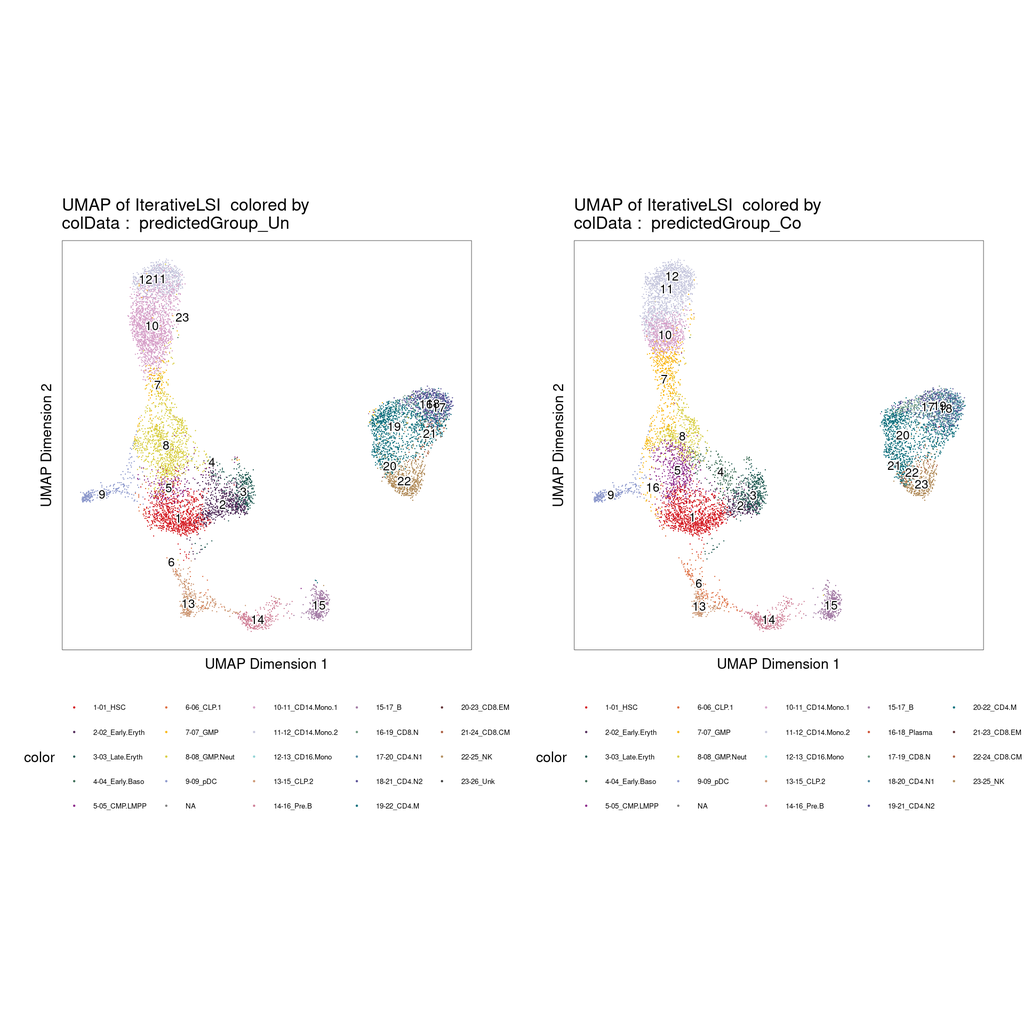

```r
ggAlignPlots(p1, p2, type = "h")
```

```r
saveArchRProject(proj, outputDirectory = "ArchRVignette", load = FALSE)
```

```
## Saving ArchRProject...
```